# Equivalent Soil-Mass (ESM) Corrections for Measuring Soil Carbon Change in Agricultural Systems

Ben Dube & Eric Potash

December 15, 2023

# 1 Introduction

This document contains supplemental material for a poster session at the 2023 Fall Meeting of the American Geophysical Union (AGU). The poster itself can be found [here](https://bubalis.github.io/doc_figures/Dube_Potash_AGU_poster.pdf).

Code and data used for these analyses can be found in a [git repository](https://github.com/bubalis/Soil_Mass_Corrections/)

These supplements are still a work in progress.

# 2 Problem

“Fixed-Depth” Comparisons Systematically Mis-Represent Soil Carbon Change.

Soil Carbon stocks are traditionally quantified as a mass per area to a reference depth (EQ 1).
$$SOC_{D, time=t (T/ha)} = SOC_{pct, t} \cdot \frac{BD_{g/cm^3, t}
\cdot D_{cm}}{100}$$

This method is biased when used to quantify SOC stock changes when soil bulk density changes between measurements, (EQ 2).

$$SOC_{D, t2} - SOC_{D, t1} \neq SOCsequest_{t1 \rightarrow t2}$$

If bulk density changes between t1 and t2, then a change in SOC to the reference depth may just reflect a different amount of soil being included in that quantification. In the simplest form, if a soil is compacted immediately before soil sampling, more soil will be included in the soil sampling than if it had not been compacted, resulting in more SOC being quantified to that depth.

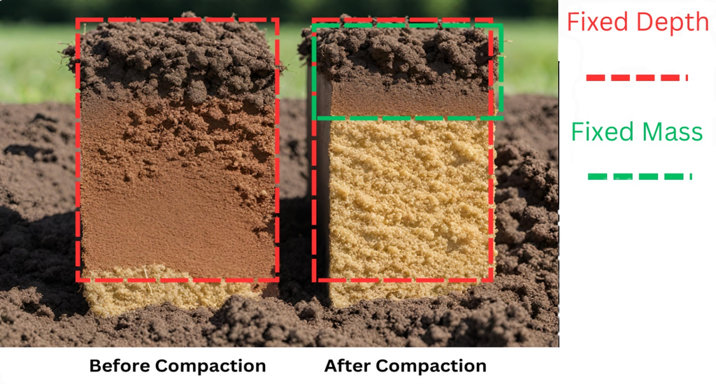

Figure 1: A Very exaggerated example of Measured Soil Mass Changing Due to Soil Compaction.

## 2.1 The Fixed Depth Approach is Biased

The bias of the Fixed-depth approach is problematic for 2 reasons.

- No-till systems are one of the most popular approaches to increasing soil carbon, but No-till can increase bulk density. Where this happens, the impact of No-till on SOC sequestration will be over-estimated using the fixed-depth approach.
- All else equal, greater SOC leads to lower bulk density in soils. When practices that increase SOC lead to decreased Bulk Density, the fixed-depth approach will underestimate SOC sequestration.

# 3 Solutions: Interpolation

There are several techniques for correcting for bulk-density related errors. All of these methods are conceptually similar, using the same basic steps.

1. At time 0, calculate SOC stocks using Equation 1.
2. At time 0, also calculate total soil mass to the quantification depth.
3. At re-measurement, use the measured values of bulk density and SOC content to estimate SOC stock to the mass defined in step 2.

Several variations on linear (Ellert and Bettany 1995; Fowler et al. 2023) and spline-based (Wendt and Hauser 2013; Haden, Yang, and DeLucia 2020) interpolation methods have been proposed; the accuracy of each of these is improved by measuring soil cores to multiple depths.

One difference between methods is whether to interpolate to a reference “total soil mass” or a reference “mineral soil mass.” Mineral soil mass is soil mass excluding organic matter. Using cumulative mineral soil mass is conceptually more precise, but only makes a small difference, as changes in SOM are almost always quite small (<2%). Cumulative mineral soil mass is used by newer approaches, including Von Haden et al and Fowler et al.

A few important points regarding interpolation of cumulative SOC stocks to a given soil mass:

- The interpolated value increases monotonically. For this reason, when a spline is used, it should use the Hyman (monotonic) method.
- In addition to the directly measured values, an additional value of (0,0) is added to the data used for interpolation, as the cumulative SOC and cumulative soil mass both start at 0.
- The simplest ESM correction on a single-depth sample is to ignore the Bulk Density measured at t2. This is mathematically equivalent to linear interpolation.
- Linear interpolation and spline interpolation on a single-depth sample are also equivalent to one another.

## 3.1 Our Proposed technique

We utilize data from the SSURGO soil database to create a reference curve for SOC accumulation with depth for a given sampling point.

This curve is normalized so that the curve correctly predicts the single point given by the single-depth sample, then the interpolation is conducted using that curve.

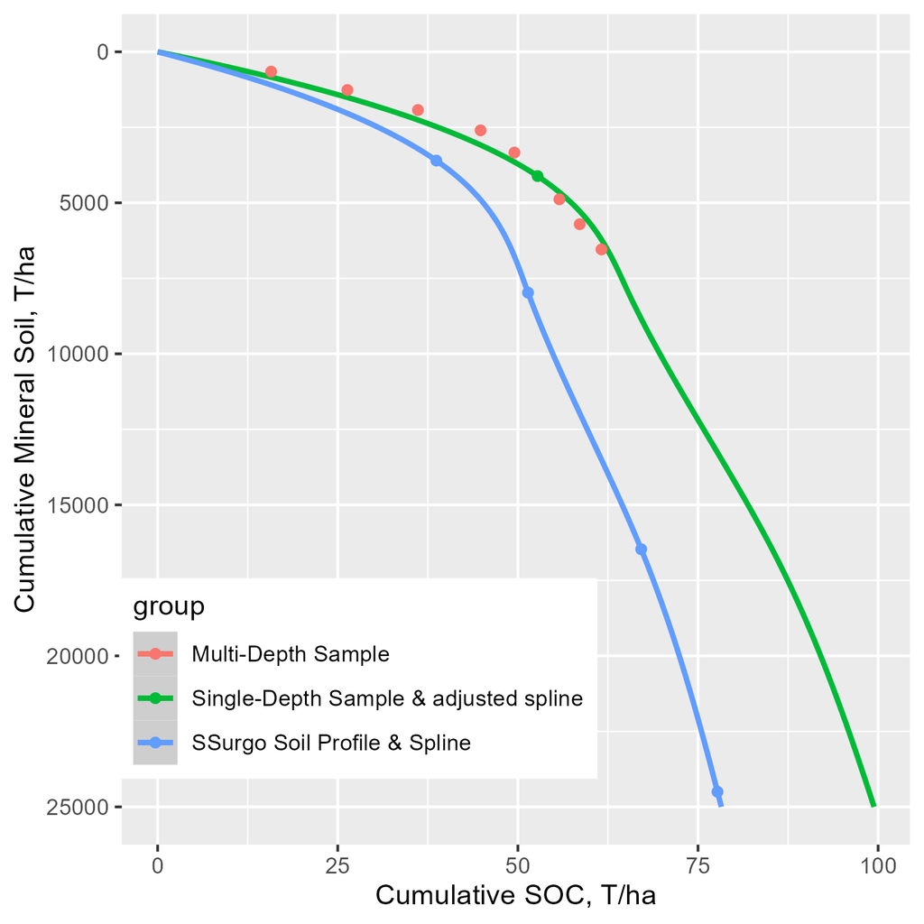

Figure 2: Conceptual diagram of our proposed technique.

Note that our technique is a little more complicated than this example, as it uses 2 different reference curves (the other is based on exponential decay of SOC with depth) and averages the two.

Theoretically, where a digital soil map database is not available, a single example reference curve could be used. In preliminary tests, a reference curve that does not vary with spatial data performs somewhat worse than the SSURGO method.

# 4 Data Sources

We utilize the following data sources for assessing ESM estimation techniques.

- Plot-level aggregates from 11 scientific papers, both observational and field-trials in the United States, mostly collated by Haddaway, et al (2017).
- High-resolution individual soil-core data from five fields in the mid-west, as described in (Potash et al. 2023).

# 5 Leave-one-out (LOO) Validation of Interpolation Methods

First, we test linear and spline-based interpolation methods using Leave-one-out Validation; simulating the exclusion of one depth-layer from a soil profile and predicting cumulative SOC to that depth.

## 5.1 Examples of Leave-One-Out Checks with Confidence intervals:

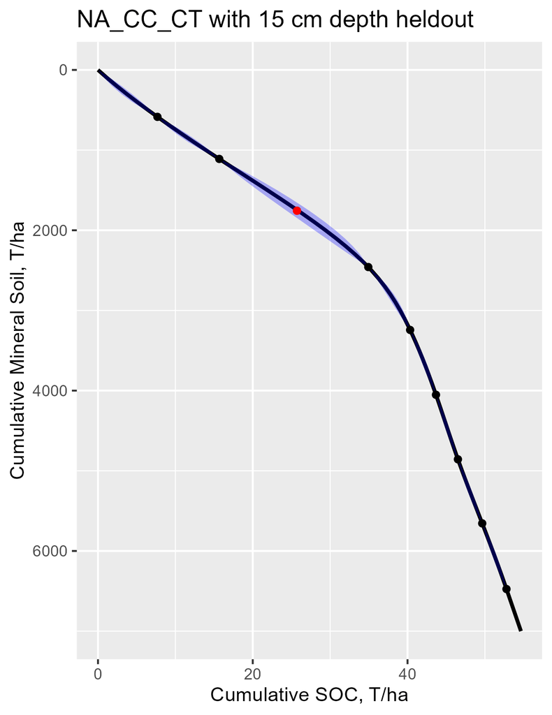

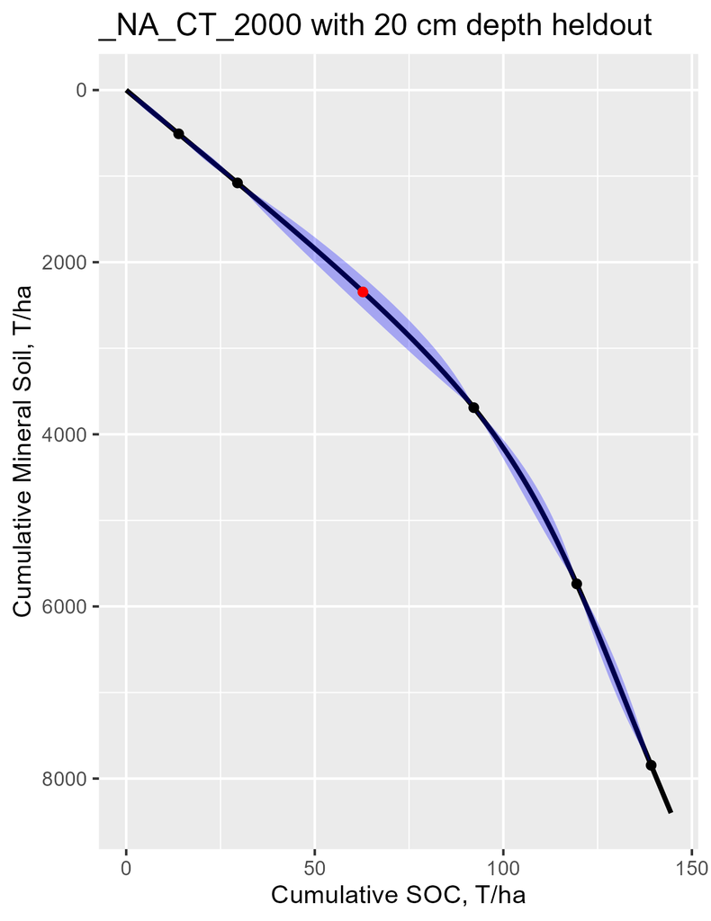

## 5.2 Interpolation results:

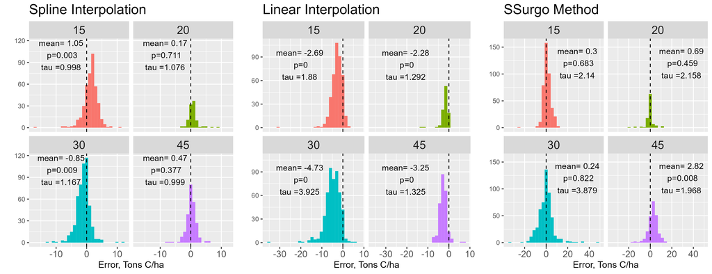

Figure 5: Errors from linear and spline-based interpolation.

Unsurprisingly, Linear Interpolation has a consistent negative bias. This is consistent with the general convexity of SOC accumulation curves; generally, SOC contents of soil decrease with depth.

Our SSurgo-based method, using a single-depth soil core has higher variance than the multi-depth methods, but generally has minimal bias. Interestingly several of the observations with the largest error come from forested or woodlot sites.

# 6 Simulating ESM comparisons to a 30-cm depth

Next, we test sampling and interpolation strategies on single or 2-depth soil samples. For each comparison, we use the ESM estimate with all of the data as the benchmark “true” value, with uncertainty derived from the LOO validation in the previous step.

We use a space-for-time design within each study or site. Whole-field aggregated data are compared to each other field in that study/site. The space-for-time design was the research design for 9 out of 11 of these studies,

For individual soil cores, each core is compared with the 3 nearest soil cores.

For the correct value of cumulative SOC at the reference soil mass, we use the interpolated value from the “full-data” spline interpolation to that depth, plus a random error. The distribution of errors is generated based on the empirical relationship between spline data-density and spline prediction error from the Leave-one- (or more)-Out validation done earlier.

For each observation, 200 “true” values are simulated using the predicted error. The true values are generated using a re-scaled beta distribution, such that they have the predicted standard deviation, but never exceed the cumulative SOC bounds of their interpolation window (i.e. the monotonicity SOC accumulation is never violated).

# 7 Estimation Techniques Evaluated

- **Linear:** Single-depth Linear Interpolation.
- **Fixed Depth:** Fixed-Depth Calculation of Carbon Stocks at t0 and t1.
- **ESM spline:** Spline-based ESM method, as implemented Von Haden et al.
- **SSURGO Mass-Correction**: Our proposed method utilizing a single depth measurement.
- **2-depth single SOC:** 2-depth core is weighed & combined in lab to create a single sample (Wendt and Hauser 2013).

The 2-depth single SOC method is described and recommended in VM0042.V2, the newest version of the Verified Carbon Standard’s Methodology for Improved Agricultural Land Management. This method is mathematically equivalent to 2-depth linear interpolation on total soil mass, but with theoretically less lab-work.

When this method was initially proposed, Wendt and Hauser (2013) proposed drawing a soil core that is deeper than the quantification depth, and splitting the core at 2 depths evenly spaced around the quantification depth. For instance, to quantify at 30 cm, a 38 cm core, divided at 22 cm might be used.

# 8 Comparison Results

Figure 6 shows some results for these comparisons.

Data are grouped by the sample depths of the 2-depth methods (not all depths are present for each data source).

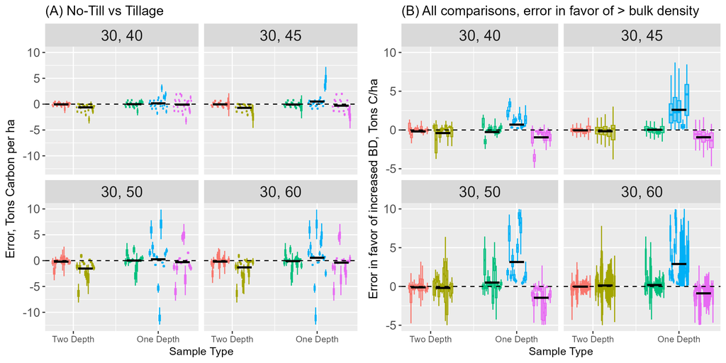

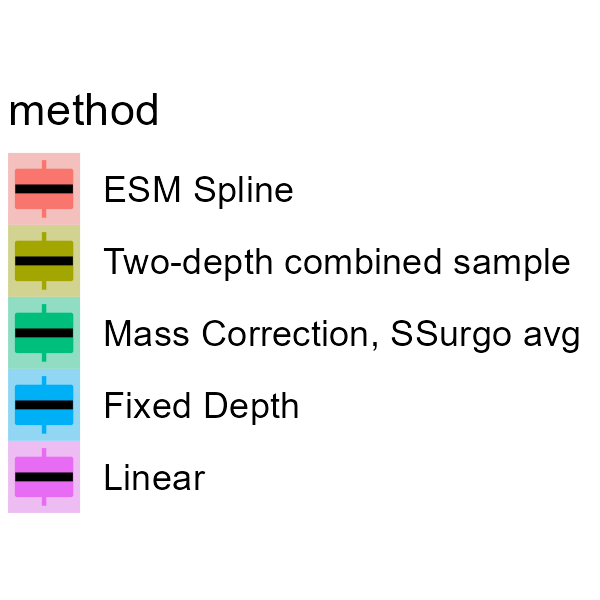

A: ESM errors for comparisons between Tillage & No-Tillage treatments.

B: ESM errors for all comparisons, in the direction of bulk density change, grouped by site.

# 9 Conclusions and Next Steps

1. Confirming previous simulation-based work, we find that spline interpolation has lower errors and bias than linear interpolation.
2. Spline interpolation, even from two-depth samples has acceptably low bias.
3. Using SSURGO-derived reference SOC-accumulation curves appears to give low-bias, low-cost ESM estimates based on a single-depth soil core.
4. Test method on more soil core data, especially high-resolution data.
5. Methods for pooling soil-databases & multi-depth cores.

# 10 Code and Data Availability

We are still working to clean up the repository associated with this project, but this will be available soon.

# References

Ellert, BH, and JR Bettany. 1995. “Calculation of Organic Matter and Nutrients Stored in Soils Under Contrasting Management Regimes.” *Canadian Journal of Soil Science* 75 (4): 529–38.

Fowler, Ames F, Bruno Basso, Neville Millar, and William F Brinton. 2023. “A Simple Soil Mass Correction for a More Accurate Determination of Soil Carbon Stock Changes.” *Scientific Reports* 13 (1): 2242.

Haddaway, Neal R, Katarina Hedlund, Louise E Jackson, Thomas Kätterer, Emanuele Lugato, Ingrid K Thomsen, Helene B Jørgensen, and Per-Erik Isberg. 2017. “How Does Tillage Intensity Affect Soil Organic Carbon? A Systematic Review.” *Environmental Evidence* 6 (1): 1–48.

Haden, Adam C von, Wendy H Yang, and Evan H DeLucia. 2020. “Soils’ Dirty Little Secret: Depth-Based Comparisons Can Be Inadequate for Quantifying Changes in Soil Organic Carbon and Other Mineral Soil Properties.” *Global Change Biology* 26 (7): 3759–70.

Potash, Eric, Kaiyu Guan, Andrew J Margenot, DoKyoung Lee, Arvid Boe, Michael Douglass, Emily Heaton, et al. 2023. “Multi-Site Evaluation of Stratified and Balanced Sampling of Soil Organic Carbon Stocks in Agricultural Fields.” *Geoderma* 438: 116587.

Wendt, JW, and S Hauser. 2013. “An Equivalent Soil Mass Procedure for Monitoring Soil Organic Carbon in Multiple Soil Layers.” *European Journal of Soil Science* 64 (1): 58–65.